# Лабораторная работа №4

Математическое моделирование

Чистов Даниил Максимович

1132236021@rudn.ru

Российский университет дружбы народов

2026-04-04

## Докладчик

- Чистов Даниил Максимович
- Студент
- Третий курс
- Российский университет дружбы народов им. П. Лумумбы

## О модели гармонических колебаний

Движение грузика на пружинке, маятника, заряда в электрическом контуре, а также эволюция во времени многих систем в физике, химии, биологии и других науках при определенных предположениях можно описать одним и тем же дифференциальным уравнением, которое в теории колебаний выступает в качестве основной модели. Эта модель называется линейным гармоническим осциллятором.

## О модели гармонических колебаний

Независимые переменные x, y определяют пространство, в котором «движется» решение. Это фазовое пространство системы, поскольку оно двумерно будем называть его фазовой плоскостью. Значение фазовых координат x, y в любой момент времени полностью определяет состояние системы. Решению уравнения движения как функции времени отвечает гладкая кривая в фазовой плоскости. Она называется фазовой траекторией. Если множество различных решений (соответствующих различным начальным условиям) изобразить на одной фазовой плоскости, возникает общая картина поведения системы. Такую картину, образованную набором фазовых траекторий, называют фазовым портретом.

## О модели SIR

Модель SIR делит всю популяцию на три взаимосвязанные группы (компартменты), что отражено в её названии:

- S — Susceptible (Восприимчивые): люди, которые не болели, не имеют иммунитета и могут заразиться.
- I — Infectious (Инфицированные/Заразные): люди, которые в данный момент больны и могут передавать инфекцию.
- R — Recovered (Выздоровевшие/Удаленные): люди, которые переболели и приобрели иммунитет (или умерли). Они больше не участвуют в процессе передачи.

Основная цель модели: не предсказать судьбу конкретного человека, а понять общую динамику эпидемии — будет ли она разрастаться, как быстро, сколько людей в итоге переболеет, как влияют карантинные меры.

## SIR в агентном подходе

Каждый агент — человек, обладающий следующими свойствами:

- status::Symbol — состояние (:S, :I, :R);
- days_infected::Int — количество дней с момента заражения (для инфицированных).

## Пространство состояний

Агенты размещаются на графе, где узлы представляют локации (города, районы), а рёбра — возможные перемещения между ними. Такой подход позволяет моделировать метапопуляционную динамику и миграцию.

## Параметры модели

- Ns — вектор численности населения по локациям;
- β_und — вероятность передачи для невыявленных случаев;
- β_det — вероятность передачи для выявленных случаев;
- infection_period — длительность заболевания (дней);
- detection_time — время до выявления заболевания;
- death_rate — вероятность летального исхода;
- reinfection_probability — вероятность повторного заражения;
- migration_rates — матрица вероятностей миграции между локациями.

## Динамика

На каждом шаге (соответствует одному дню) для каждого агента выполняются следующие процессы:

- Миграция — агент может переместиться в другую локацию с вероятностью, заданной матрицей migration_rates.
- Передача инфекции — если агент инфицирован, он может заразить восприимчивых агентов в той же локации. Количество заражённых за день определяется пуассоновским процессом с интенсивностью, зависящей от статуса выявления (β_und или β_det).
- Обновление счётчика — для инфицированных увеличивается days_infected.
- Выздоровление или смерть — если days_infected достиг infection_period, агент либо выздоравливает (переходит в R), либо умирает (удаляется из модели) с вероятностью death_rate. Выздоровевшие могут быть повторно инфицированы с вероятностью reinfection_probability.

# Выполнение лабораторной работы

## Выполнение лабораторной работы

В папке lab04 инициализирую проект для данной лабораторной работы

[figure not shown]

Рисунок 1: Инициализация проекта

## Работа с SIR

### Базовая экспериент

Предварительно создаю файл sir_model.jl в папке /src. Он будет использоваться последующими программами. Этот код и является моделью SIR.

Создаю файл sir_run_basic.jl в папке /scripts. Это базовый эксперимент.

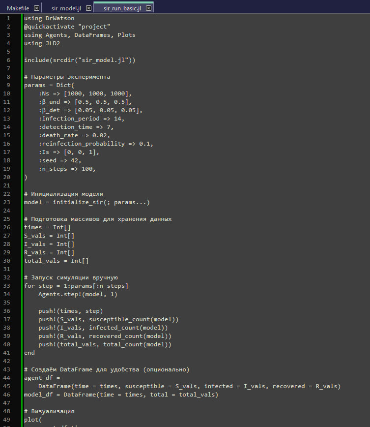

Рисунок 2: Создание файла sir_run_basic.jl

## Базовая экспериент

Код успешно работает - результаты расположены в соответствующих папках.

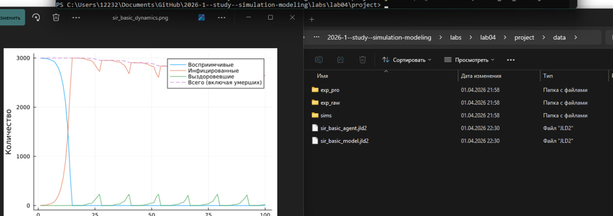

Рисунок 3: Результат работы sir_run_basic.jl

## Базовая экспериент

Ниже представлен график базового эксперимента.

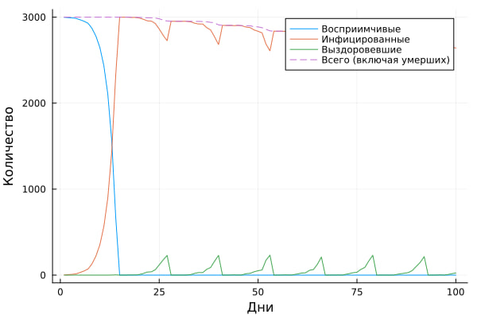

Рисунок 4: Базовый эксперимент SIR

## Дополнительное задание №1

Требуется определить базовое репродуктивное число R₀ по формуле R₀ = β/γ, где γ = 1/infection_period. Затем сравнить с наблюдаемой динамикой.

## Дополнительное задание №1

Требуемые для решения задачи параметры можно найти в коде:

- β_und => [0.5, 0.5, 0.5], т. е. всегда 0.5
- infection_period => 14

Тогда $R_{0} = (0.5) * 14 = 7$

Так как базовое репродуктивное число значительно больше 1, следует ожидать быстрой рост. Это соответствует полученному результату на графике

### Сканирование коэффициента заразности

По заданию требуется создать код sir_scan_beta.jl.

Данный код исследует, как изменение базовой заразности (β_und и пропорционально β_det) влияет на эпидемические показатели: пик заболеваемости, долю переболевших, число умерших. Выполняется параметрическое сканирование с несколькими повторными прогонами для учёта стохастичности.

## Сканирование коэффициента заразности

Код успешно работает.

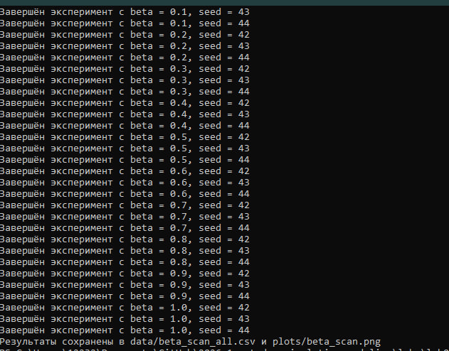

Рисунок 5: Работа sir_scan_beta.jl

## Сканирование коэффициента заразности

Ниже представлен график, полученный в результате работы кода.

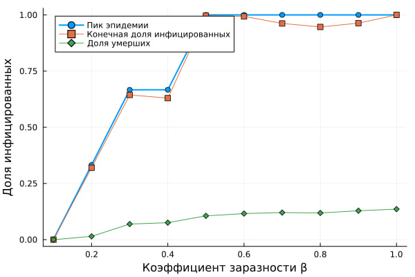

Рисунок 6: График зависимости коэффициента заразности и эпидимических показателей

## Дополнительное задание №2

Требуется:

- Найти минимальное значение $\beta$, при котором возникает эпидемия (пик I > 5% популяции).
- Сравнить с теоретическим порогом $R_{0} = 1$.

## Дополнительное задание №2

### Исследование эффекта миграции

Требуется создать код, который исследует, как интенсивность перемещения людей между городами влияет на скорость распространения эпидемии (время достижения пика) и масштаб пика. Инфекция начинается только в одном городе, остальные изначально здоровы.

## Исследование эффекта миграции

Код успешно работает.

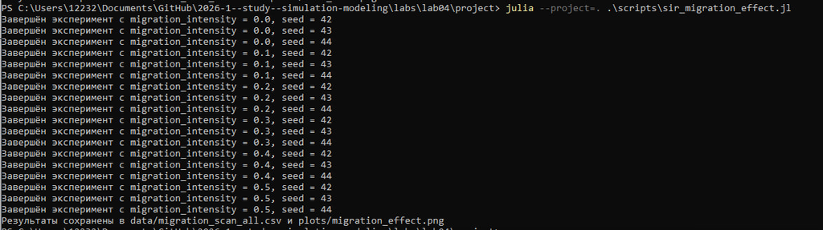

Рисунок 7: Работа sir_migration_effect.jl

## Исследование эффекта миграции

Ниже представлен график, полученный в результате работы кода.

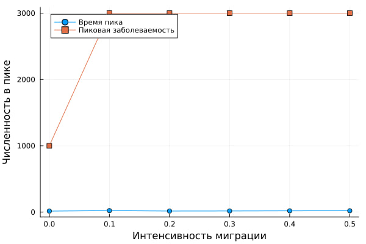

Рисунок 8: График зависимости интенсивности перемещения людей между городами и скорости распространения эпидемии

## Многокритериальная оптимизация параметров

По заданию был создан код, который ищет оптимальные комбинации параметров, минимизирующие одновременно два критерия: пиковую заболеваемость и долю умерших.

## Многокритериальная оптимизация параметров

- Определяет целевую функцию cost_multi(x), которая для заданных параметров запускает несколько повторных симуляций (5) и возвращает среднюю долю пиковой заболеваемости и среднюю долю умерших.
- Запускает оптимизатор с методом :borg_moea, максимизирующим (или минимизирующим) два критерия.
- Результат оптимизации — набор точек на Парето-фронте.

## Многокритериальная оптимизация параметров

Код успешно работает и приводит следующие результаты в терминале.

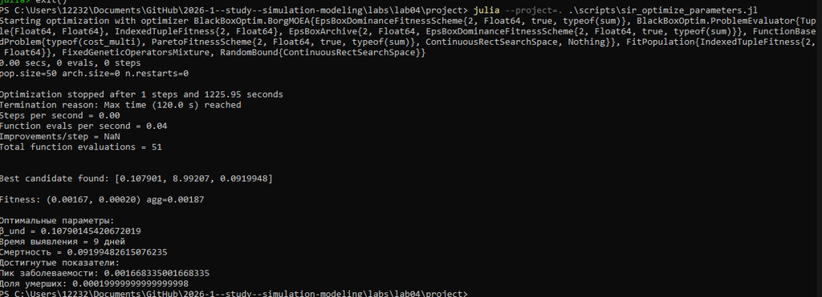

Рисунок 9: Результат работы sir_optimize_parameters.jl

## Сводная визуализация результатов

Для выполнения работы также требуется создать код, который загружает результаты параметрического сканирования (файл data/beta_scan_all.csv, созданный scan_beta.jl) и строит единый составной график, объединяющий три панели:

- пик эпидемии и конечная доля инфицированных;
- число умерших;
- доля выздоровевших.

## Сводная визуализация результатов

Код успешно работает. В результате был получен следующий график. Верхний: зависимость пиковой и конечной доли инфицированных от β. Средний: зависимость числа умерших от β. Нижний: зависимость доли выздоровевших от β

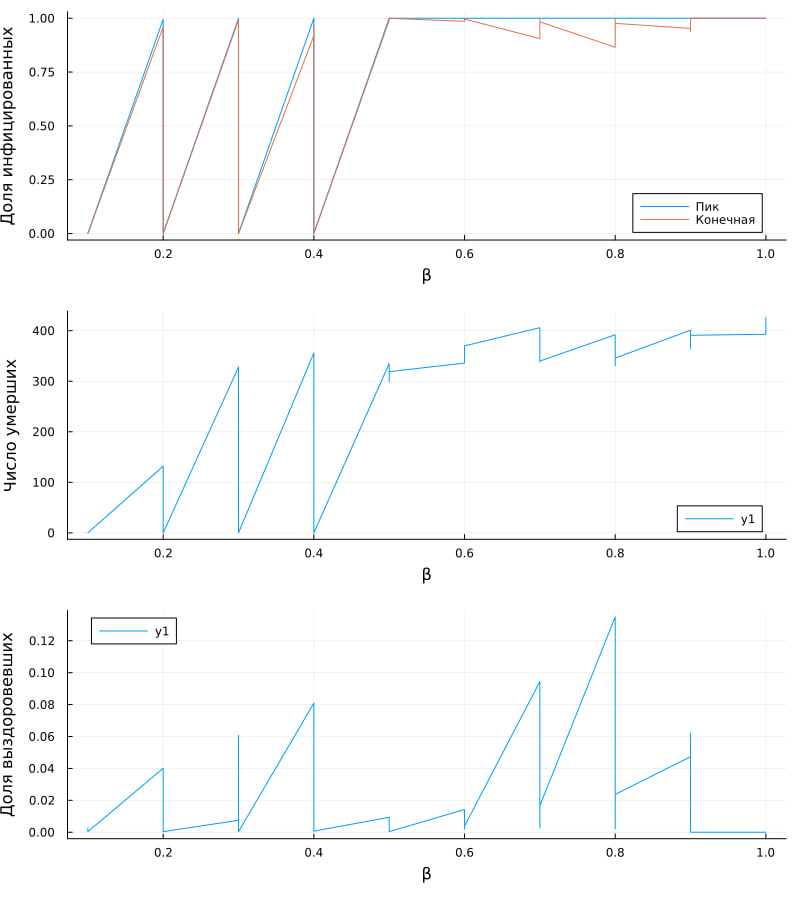

Рисунок 10: Результат работы sir_visualize_dynamics.jl

## Выводы

В результате выполнения данной лабораторной работы я закрепил навыки работы с агентным подходом имитационного моделирования на примере модели SIR, реализованной на Julia. Разобрался в самой модели и интегрировал её реализацию в данный отчёт.

## Список литературы

[Лабораторная работа №4](https://esystem.rudn.ru/mod/resource/view.php?id=1356134)